# 공공데이터분석_2023기말고사_목(문제)

- 공공데이터분석 기말고사 2023.06.22 (목)

```python
##################################################
############### 문제 풀기 전 주의사항 ##############
##################################################

# 시험시간 내 인터넷 사용 금지, 시험문제 다운로드, 업로드 시에만 가능
# (시험 중, 핸드폰이나 인터넷 사용을 포함한 부정행위 적발시 0점 처리).

# ipynb 시험파일, html 시험파일, 데이터를 다운 받고,
# ipynb 시험 파일은 파일명 수정 -> da목_기말_20181234_홍길동.ipynb.

# html 파일의 실행결과를 참고하여, ipynb 파일의 #=== 코드작성 ===# 부분에 코드를 작성
# (ipynb파일의 실행결과는 코드 작성과정에서 사라질 수 있음).

# 맨 위의 셀을 우선 실행.
# 랜덤 값을 입력으로하는 문제는 주어진 실행결과와 다른 실행결과가 나올 수 있음.
# 문제에 주어진 코드는 수정 불가.

# 코드는 다른 값을 갖는 데이터에서도 동작을 해야만 정답으로 인정
# (문제의 데이터 값 자체를 가지고 결과를 만들면 오답 처리)

# 시험 도중 anaconda prompt (검은창) 지우지 말것.
# 갑자기 컴퓨터에 문제가 생길수 있으니, 시험 중간중간에 파일 저장 (crtl+s) 할 것.

# 시험이 끝나면 실행결과를 모두 확인하고 작성한 ipynb 파일 저장 후,
# 작성한 ipynb을 < 캔버스 --> 과제 --> 중간고사> 에 업로드.
```

```python
# 사용할 패키지를 import합니다
import sys
print('python', sys.version)

import numpy as np
print('numpy', np.__version__)

import pandas as pd
print('pandas', pd.__version__)

import matplotlib as mpl
print('matplotlib', mpl.__version__)

import matplotlib.pyplot as plt
plt.rc("font", family="Malgun Gothic") # window

import seaborn as sns
print('seaborn', sns.__version__)

# 결과 확인을 용이하게 하기 위한 코드
from IPython.core.interactiveshell import InteractiveShell
InteractiveShell.ast_node_interactivity = 'all'

# # 경고 메시지는 출력되지 않게 합니다.
# import warnings
# warnings.filterwarnings("ignore")
```

```
python 3.7.16 (default, Jan 17 2023, 16:06:28) [MSC v.1916 64 bit (AMD64)]
numpy 1.21.5
pandas 1.3.5
matplotlib 3.5.2
seaborn 0.12.2
```

# 문제1

- 각 시군구별로, 상점들의 경도 평균을 아래와 같이 series로 나타내시오
- 단 시군구명을 가나다 순으로 나타내시오

```python
d1=pd.read_csv("data/dat4.csv", sep=',', index_col=0).reset_index(drop=True)
d1.head()

## 코드작성
```

|  | 상호명 | 상권업종대분류명 | 상권업종중분류명 | 상권업종소분류명 | 시도명 | 시군구명 | 행정동명 | 법정동명 | 도로명주소 | 경도 | 위도 |
| --- | --- | --- | --- | --- | --- | --- | --- | --- | --- | --- | --- |
| 0 | 네일스토리 | 생활서비스 | 이/미용/건강 | 발/네일케어 | 서울특별시 | 구로구 | 구로3동 | 구로동 | 서울특별시 구로구 디지털로32가길 16 | 126.898569 | 37.482941 |
| 1 | 위치캔들 | 소매 | 종합소매점 | 생활용품판매 | 서울특별시 | 서대문구 | 신촌동 | 창천동 | 서울특별시 서대문구 신촌로3가길 21 | 126.930150 | 37.558207 |
| 2 | 카페쎄리오 | 음식 | 커피점/카페 | 커피전문점/카페/다방 | 서울특별시 | 동대문구 | 휘경1동 | 휘경동 | 서울특별시 동대문구 망우로 71 | 127.061168 | 37.590012 |
| 3 | 현대세탁 | 생활서비스 | 세탁/가사서비스 | 세탁소/빨래방 | 서울특별시 | 구로구 | 개봉2동 | 개봉동 | 서울특별시 구로구 개봉로20길 158 | 126.860723 | 37.492034 |
| 4 | 미아현대비너스 | 소매 | 의복의류 | 셔츠/내의/속옷 | 서울특별시 | 성북구 | 길음2동 | 길음동 | 서울특별시 성북구 동소문로 315 | 127.028726 | 37.608392 |

```
시군구명
강남구     127.045486
강동구     127.137756
강북구     127.024380
강서구     126.840220
관악구     126.937488
광진구     127.081048
구로구     126.871617
금천구     126.897127
노원구     127.067128
도봉구     127.038044
동대문구    127.053382
동작구     126.950257
마포구     126.926040
서대문구    126.940221
서초구     127.012295
성동구     127.039482
성북구     127.028804
송파구     127.111601
양천구     126.858259
영등포구    126.904945
용산구     126.980151
은평구     126.919718
종로구     126.992190
중구      126.995446
중랑구     127.088217
Name: 경도, dtype: float64
```

# 문제2

- 상권업종소분류명에 '핸드폰'이 포함되어있는 상점들을 아래와 같이 시군구별로 scatterplot 하시오 (seaborn 사용)

|  | 상호명 | 상권업종대분류명 | 상권업종중분류명 | 상권업종소분류명 | 시도명 | 시군구명 | 행정동명 | 법정동명 | 도로명주소 | 경도 | 위도 |
| --- | --- | --- | --- | --- | --- | --- | --- | --- | --- | --- | --- |
| 8748 | 예진쥬얼리 | 소매 | 시계/귀금속소매 | 시계/귀금속 | 서울특별시 | 강동구 | 성내2동 | 성내동 | 서울특별시 강동구 천호대로170길 104 | 127.131242 | 37.530998 |
| 2916 | 촌마루추어탕 | 음식 | 한식 | 추어탕전문 | 서울특별시 | 동대문구 | 장안1동 | 장안동 | 서울특별시 동대문구 장한로25길 45 | 127.068652 | 37.571852 |
| 886 | 멕시칸바베큐 | 음식 | 양식 | 바베큐전문 | 서울특별시 | 광진구 | 화양동 | 화양동 | 서울특별시 광진구 광나루로 428 | 127.076909 | 37.545822 |
| 5020 | 현대지물포인테리어 | 소매 | 가정/주방/인테리어 | 인테리어/욕실용품/커튼 | 서울특별시 | 동대문구 | 장안2동 | 장안동 | 서울특별시 동대문구 장한로26다길 21 | 127.073241 | 37.570626 |
| 1970 | RAINBOW | 소매 | 의복의류 | 일반의류 | 서울특별시 | 성북구 | 종암동 | 종암동 | 서울특별시 성북구 종암로 1 | 127.036271 | 37.590640 |

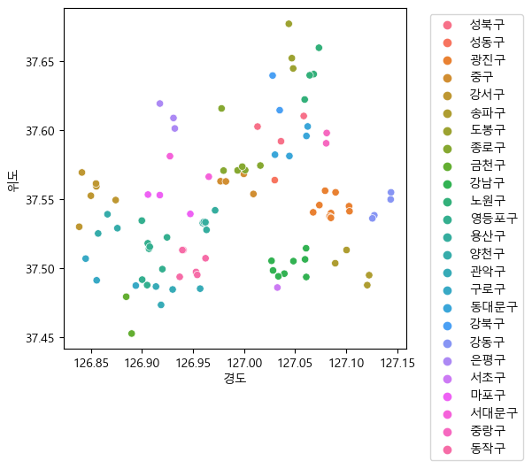

```python
fig=plt.figure(figsize=(5,5), dpi=100)
ax=fig.subplots()

d1=pd.read_csv("data/dat4.csv", sep=',', index_col=0).reset_index(drop=True)
d1.sample(5)

## 코드작성


_=ax.legend(bbox_to_anchor=(1.05,1),loc=2)
```

# 문제3

- 위도가 "두번째"로 큰 상점의 상호명과 시군구명을 출력하시오

```python
d1=pd.read_csv("data/dat4.csv", sep=',', index_col=0).reset_index(drop=True)
d1.head()

#=== 코드작성 ===#
```

|  | 상호명 | 상권업종대분류명 | 상권업종중분류명 | 상권업종소분류명 | 시도명 | 시군구명 | 행정동명 | 법정동명 | 도로명주소 | 경도 | 위도 |
| --- | --- | --- | --- | --- | --- | --- | --- | --- | --- | --- | --- |
| 0 | 네일스토리 | 생활서비스 | 이/미용/건강 | 발/네일케어 | 서울특별시 | 구로구 | 구로3동 | 구로동 | 서울특별시 구로구 디지털로32가길 16 | 126.898569 | 37.482941 |
| 1 | 위치캔들 | 소매 | 종합소매점 | 생활용품판매 | 서울특별시 | 서대문구 | 신촌동 | 창천동 | 서울특별시 서대문구 신촌로3가길 21 | 126.930150 | 37.558207 |
| 2 | 카페쎄리오 | 음식 | 커피점/카페 | 커피전문점/카페/다방 | 서울특별시 | 동대문구 | 휘경1동 | 휘경동 | 서울특별시 동대문구 망우로 71 | 127.061168 | 37.590012 |
| 3 | 현대세탁 | 생활서비스 | 세탁/가사서비스 | 세탁소/빨래방 | 서울특별시 | 구로구 | 개봉2동 | 개봉동 | 서울특별시 구로구 개봉로20길 158 | 126.860723 | 37.492034 |
| 4 | 미아현대비너스 | 소매 | 의복의류 | 셔츠/내의/속옷 | 서울특별시 | 성북구 | 길음2동 | 길음동 | 서울특별시 성북구 동소문로 315 | 127.028726 | 37.608392 |

|  | 상호명 | 시군구명 |
| --- | --- | --- |
| 3332 | 본스치킨호프 | 노원구 |

# 문제4

- '상권업종중분류명'이 '의복의류'인 상점들에 대해서, '상권업종소분류명' 별 상점 개수를 plot 하시오
- 단, 소분류명을 상점 개수가 많은 순서로 sorting 하시오
- 또한, seaborn의 countplot을 이용하여 plot하시오 (sorting은 다른 방법 사용 가능)

|  | 상호명 | 상권업종대분류명 | 상권업종중분류명 | 상권업종소분류명 | 시도명 | 시군구명 | 행정동명 | 법정동명 | 도로명주소 | 경도 | 위도 |
| --- | --- | --- | --- | --- | --- | --- | --- | --- | --- | --- | --- |
| 0 | 네일스토리 | 생활서비스 | 이/미용/건강 | 발/네일케어 | 서울특별시 | 구로구 | 구로3동 | 구로동 | 서울특별시 구로구 디지털로32가길 16 | 126.898569 | 37.482941 |
| 1 | 위치캔들 | 소매 | 종합소매점 | 생활용품판매 | 서울특별시 | 서대문구 | 신촌동 | 창천동 | 서울특별시 서대문구 신촌로3가길 21 | 126.930150 | 37.558207 |
| 2 | 카페쎄리오 | 음식 | 커피점/카페 | 커피전문점/카페/다방 | 서울특별시 | 동대문구 | 휘경1동 | 휘경동 | 서울특별시 동대문구 망우로 71 | 127.061168 | 37.590012 |
| 3 | 현대세탁 | 생활서비스 | 세탁/가사서비스 | 세탁소/빨래방 | 서울특별시 | 구로구 | 개봉2동 | 개봉동 | 서울특별시 구로구 개봉로20길 158 | 126.860723 | 37.492034 |
| 4 | 미아현대비너스 | 소매 | 의복의류 | 셔츠/내의/속옷 | 서울특별시 | 성북구 | 길음2동 | 길음동 | 서울특별시 성북구 동소문로 315 | 127.028726 | 37.608392 |

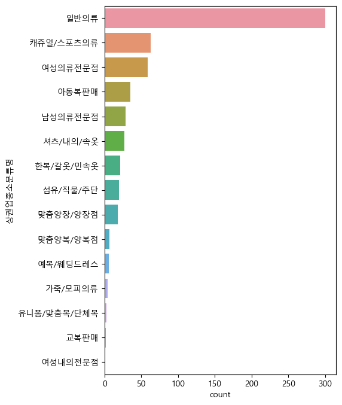

```python
fig=plt.figure(figsize=(5,8), dpi=100)
ax=fig.subplots()
d1=pd.read_csv("data/dat4.csv", sep=',', index_col=0).reset_index(drop=True)
d1.head()

## 코드작성
```

# 문제5

- 주어진 d1의 열 별 nan의 개수를 아래와 같이 시각화 하시오 (seaborn 사용)
- 단 c1,c2, ..., c6 순서로 bargraph를 그릴것

|  | C1 | C2 | C3 | C4 | C5 | C6 |
| --- | --- | --- | --- | --- | --- | --- |
| 0 | B | 3.0 | 3.0 | DD산 | NaN | 1.045587 |
| 1 | E | 1.0 | NaN | A | a | -0.195618 |
| 2 | E | NaN | NaN | DD | a | 0.052008 |
| 3 | D | 2.0 | 1.0 | 바다2 | NaN | -0.036650 |
| 4 | E | 2.0 | 1.0 | A산 | a | 0.743268 |

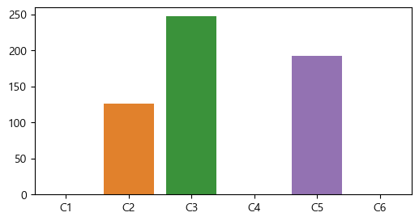

```python
fig=plt.figure(figsize=(6,3), dpi=100)
ax=fig.subplots()

d1=pd.read_csv("data/dat1.csv", sep=',', encoding='cp949').reset_index(drop=True)
d1.head()
## 코드작성
```

# 문제6

- C1 별, C5 별 C6 최대값을 pandas plot으로 아래와 같이 plot 하시오

|  | C1 | C2 | C3 | C4 | C5 | C6 |
| --- | --- | --- | --- | --- | --- | --- |
| 0 | B | 3.0 | 3.0 | DD산 | NaN | 1.045587 |
| 1 | E | 1.0 | NaN | A | a | -0.195618 |
| 2 | E | NaN | NaN | DD | a | 0.052008 |
| 3 | D | 2.0 | 1.0 | 바다2 | NaN | -0.036650 |
| 4 | E | 2.0 | 1.0 | A산 | a | 0.743268 |

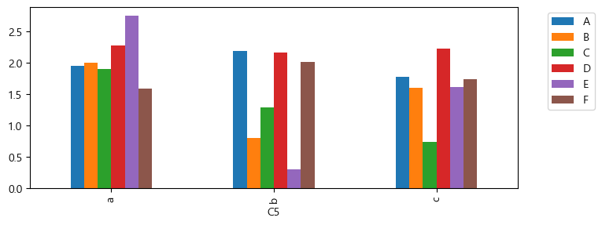

```python
fig=plt.figure(figsize=(8,3), dpi=100)
ax=fig.subplots()

d1=pd.read_csv("data/dat1.csv", sep=',', encoding='cp949').reset_index(drop=True)
d1.head()

## 코드작성

_=ax.legend(bbox_to_anchor=(1.05,1),loc=2)
```

# 문제7

- apply 함수 f1을 적용하여, C1에 있는 알파벳이 C4에 포함되어 있는 행만 추출한 dataframe을 출력하였다.
- f1을 알맞게 정의하여 아래 결과를 도출하시오

```python
d1=pd.read_csv("data/dat1.csv", sep=',', encoding='cp949').reset_index(drop=True)
d1.head()


def f1(row):
    ## 코드작성


s1=d1.apply(f1, axis=1)
d1.loc[s1=='P']
```

|  | C1 | C2 | C3 | C4 | C5 | C6 |
| --- | --- | --- | --- | --- | --- | --- |
| 0 | B | 3.0 | 3.0 | DD산 | NaN | 1.045587 |
| 1 | E | 1.0 | NaN | A | a | -0.195618 |
| 2 | E | NaN | NaN | DD | a | 0.052008 |
| 3 | D | 2.0 | 1.0 | 바다2 | NaN | -0.036650 |
| 4 | E | 2.0 | 1.0 | A산 | a | 0.743268 |

|  | C1 | C2 | C3 | C4 | C5 | C6 |
| --- | --- | --- | --- | --- | --- | --- |
| 57 | D | 2.0 | NaN | DD산 | NaN | 0.325499 |
| 60 | D | 2.0 | 3.0 | DD산 | NaN | -0.170020 |
| 99 | B | 1.0 | 2.0 | 바다B | a | 0.022785 |
| 105 | B | 1.0 | NaN | 바다B | c | 0.611728 |
| 112 | B | 3.0 | 1.0 | 바다B | c | 0.099860 |
| 141 | D | NaN | 2.0 | DD산 | a | -0.371161 |
| 148 | A | NaN | NaN | A산 | a | 0.477829 |
| 162 | D | 1.0 | 2.0 | DD산 | c | -0.709194 |
| 169 | B | NaN | 1.0 | 바다B | NaN | 1.651424 |
| 187 | D | 1.0 | 1.0 | DD산 | NaN | 0.446096 |
| 193 | D | 2.0 | NaN | DD산 | a | 2.118605 |
| 204 | B | 1.0 | NaN | 바다B | NaN | -0.340976 |
| 221 | B | 1.0 | NaN | 바다B | NaN | -1.707110 |
| 244 | A | 1.0 | 3.0 | A산 | b | 2.191652 |
| 257 | D | 2.0 | NaN | DD산 | NaN | 0.882463 |
| 269 | B | 3.0 | 2.0 | 바다B | b | 0.199847 |
| 284 | D | 2.0 | 2.0 | DD산 | b | -0.457542 |
| 291 | A | 1.0 | 2.0 | A산 | b | 1.112980 |
| 296 | B | 3.0 | 2.0 | 바다B | a | -1.399147 |
| 313 | D | 1.0 | NaN | DD산 | NaN | 1.117886 |
| 346 | A | 3.0 | NaN | A산 | NaN | 0.925823 |
| 364 | B | 1.0 | 3.0 | 바다B | b | -0.116661 |
| 378 | A | 1.0 | 3.0 | A산 | a | 1.952043 |
| 385 | B | 3.0 | 1.0 | B | NaN | -0.227877 |
| 399 | D | 2.0 | 1.0 | DD산 | NaN | -2.845548 |
| 409 | A | 3.0 | 3.0 | A산 | NaN | -0.048263 |
| 420 | D | 1.0 | NaN | DD산 | a | 0.338622 |
| 421 | D | 3.0 | NaN | DD산 | b | 0.209150 |
| 424 | B | 1.0 | NaN | 바다B | a | -1.928373 |
| 434 | A | 1.0 | 1.0 | A산 | NaN | -0.589127 |
| 479 | D | NaN | NaN | DD산 | b | -0.029926 |
| 491 | D | NaN | 1.0 | DD산 | c | 0.196306 |

# 문제8

```python
## 힌트: 소숫점 2자리까지 표현하기
s1=pd.Series([1.2351,2.652,3.658])
s1
s1.round(2)
```

```
0    1.2351
1    2.6520
2    3.6580
dtype: float64
```

```
0    1.24
1    2.65
2    3.66
dtype: float64
```

- ====== 문제8 ======

|  | C1 | C2 | C3 | C4 | C5 | C6 |
| --- | --- | --- | --- | --- | --- | --- |
| 0 | B | 3.0 | 3.0 | DD산 | NaN | 1.045587 |
| 1 | E | 1.0 | NaN | A | a | -0.195618 |
| 2 | E | NaN | NaN | DD | a | 0.052008 |
| 3 | D | 2.0 | 1.0 | 바다2 | NaN | -0.036650 |
| 4 | E | 2.0 | 1.0 | A산 | a | 0.743268 |

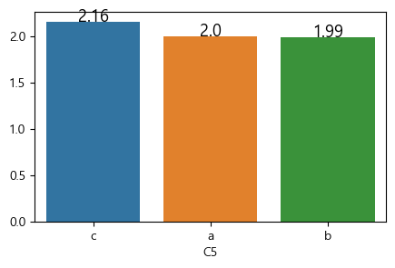

```python
fig=plt.figure(figsize=(5,3), dpi=100)
ax=fig.subplots()

d1=pd.read_csv("data/dat1.csv", sep=',', encoding='cp949').reset_index(drop=True)
d1.head()

## 코드작성
```

# 문제9

- 학년 별로, 가장 조금 신청한 과목과 해당 과목의 신청 학생 수를 담은 dataframe을 출력하시오

```python
d1=pd.read_table('data/dat2.csv', sep=',', encoding='cp949')
d1.head()

## 코드작성
```

|  | 학년 | 과목 | 동아리 | 신청월 |
| --- | --- | --- | --- | --- |
| 0 | 3 | his | B | 12 |
| 1 | 1 | eng | B | 7 |
| 2 | 2 | his | B | 5 |
| 3 | 2 | eng | B,C | 9 |
| 4 | 1 | mat | B | 4 |

|  | 학년 | 과목 | 학생수 |
| --- | --- | --- | --- |
| 8 | 1 | his | 23 |
| 7 | 2 | mat | 27 |
| 6 | 3 | eng | 33 |

# 문제10

- d1의 '신청월' 값을 아래와 같이 세 그룹으로 mapping 한 결과를 '학기' column으로 추가하여 출력하시오
- 1) '신청월'이 [3,4,5,6] 중 하나이면 'spring'을
- 2) '신청월'이 [9,10,11,12] 중 하나이면 'fall'을
- 3) 그 나머지 값은 'vacation'을 학기 column에 넣는다.

```python
d1=pd.read_table('data/dat2.csv', sep=',', encoding='cp949')
d1

## 코드작성
```

|  | 학년 | 과목 | 동아리 | 신청월 |
| --- | --- | --- | --- | --- |
| 0 | 3 | his | B | 12 |
| 1 | 1 | eng | B | 7 |
| 2 | 2 | his | B | 5 |
| 3 | 2 | eng | B,C | 9 |
| 4 | 1 | mat | B | 4 |
| ... | ... | ... | ... | ... |
| 495 | 3 | his | A,C | 11 |
| 496 | 1 | mat | A,B | 5 |
| 497 | 3 | his | A,B,C | 12 |
| 498 | 3 | his | B | 12 |
| 499 | 3 | mat | A,C | 7 |

500 rows × 4 columns

|  | 학년 | 과목 | 동아리 | 신청월 | 학기 |
| --- | --- | --- | --- | --- | --- |
| 0 | 3 | his | B | 12 | fall |
| 1 | 1 | eng | B | 7 | vacation |
| 2 | 2 | his | B | 5 | spring |
| 3 | 2 | eng | B,C | 9 | fall |
| 4 | 1 | mat | B | 4 | spring |
| ... | ... | ... | ... | ... | ... |
| 495 | 3 | his | A,C | 11 | fall |
| 496 | 1 | mat | A,B | 5 | spring |
| 497 | 3 | his | A,B,C | 12 | fall |
| 498 | 3 | his | B | 12 | fall |
| 499 | 3 | mat | A,C | 7 | vacation |

500 rows × 5 columns

# 문제11

- A,B,C 각 동아리에 가입한 학년 분포를 아래와 같이 나타내시오 (pandas plot 사용)
- 단 두 개 이상의 동아리에 가입한 경우 각 동아리에 모두 가입한 것으로 간주 한다.

|  | 학년 | 과목 | 동아리 | 신청월 |
| --- | --- | --- | --- | --- |
| 0 | 3 | his | B | 12 |
| 1 | 1 | eng | B | 7 |
| 2 | 2 | his | B | 5 |
| 3 | 2 | eng | B,C | 9 |
| 4 | 1 | mat | B | 4 |
| ... | ... | ... | ... | ... |
| 495 | 3 | his | A,C | 11 |
| 496 | 1 | mat | A,B | 5 |
| 497 | 3 | his | A,B,C | 12 |
| 498 | 3 | his | B | 12 |
| 499 | 3 | mat | A,C | 7 |

500 rows × 4 columns

```
[Text(0, 0, '1'), Text(1, 0, '2'), Text(2, 0, '3')]
```

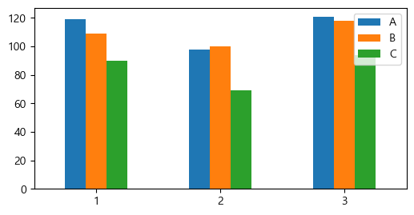

```python
fig=plt.figure(figsize=(6,3), dpi=100)
ax=fig.subplots()

d1=pd.read_table('data/dat2.csv', sep=',', encoding='cp949')
d1

## 코드작성

ax.set_xticklabels(ax.get_xticklabels(), rotation=0)
```

# 문제12

- 월별 신청 과목수를 seaborn의 pointplot으로 아래와 같이 나타내시오
- 단, 월 순서 (1,2,...,11,12)로 나타내시오

|  | 학년 | 과목 | 동아리 | 신청월 |
| --- | --- | --- | --- | --- |
| 0 | 3 | his | B | 12 |
| 1 | 1 | eng | B | 7 |
| 2 | 2 | his | B | 5 |
| 3 | 2 | eng | B,C | 9 |
| 4 | 1 | mat | B | 4 |
| ... | ... | ... | ... | ... |
| 495 | 3 | his | A,C | 11 |
| 496 | 1 | mat | A,B | 5 |
| 497 | 3 | his | A,B,C | 12 |
| 498 | 3 | his | B | 12 |
| 499 | 3 | mat | A,C | 7 |

500 rows × 4 columns

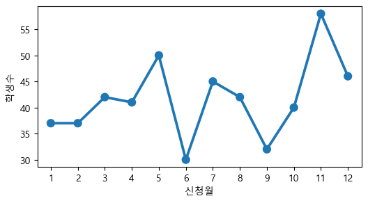

```python
fig=plt.figure(figsize=(6,3), dpi=100)
ax=fig.subplots()

d1=pd.read_table('data/dat2.csv', sep=',', encoding='cp949')
d1

## 코드작성
```

# 문제13

- 주어진 d1에 있는 공원을 아래의 조건에 맞게 folium을 활용하여 지도에 표시하시오
- 1) 공원구분이 '근린공원'이면 color='red', '수변공원'이면 color='green'으로 지정하시오
- 2) 공원구분이 '근린공원', '수변공원'이 아닌 공원은 지도에 표시하지 마시오
- 3) folium.Marker 함수의 tooltip을 사용하고, tooltip시 공원명 나오게 코딩

```python
import folium

d1=pd.read_table('data/dat6.csv', sep=',', encoding='cp949').drop(columns=['공원보유시설(유희시설)','공원보유시설(교양시설)','공원보유시설(기타시설)','관리기관명','제공기관코드','Unnamed: 19'])
d1 = d1.loc[(d1["경도"] < 132) & (d1["위도"] > 32)].copy()
d1=d1.iloc[::600].reset_index(drop=True)
d1.head()
d1['공원구분'].value_counts()


lat = d1["위도"].mean()
long = d1["경도"].mean()

m = folium.Map([lat, long], zoom_start=7, tiles='Stamen Toner')

#=== 코드작성 ===#

m
```

|  | 관리번호 | 공원명 | 공원구분 | 소재지도로명주소 | 소재지지번주소 | 위도 | 경도 | 공원면적 | 공원보유시설(운동시설) | 공원보유시설(편익시설) | 지정고시일 | 전화번호 | 데이터기준일자 | 제공기관명 |
| --- | --- | --- | --- | --- | --- | --- | --- | --- | --- | --- | --- | --- | --- | --- |
| 0 | 26440-00001 | 구랑공원 | 문화공원 | NaN | 부산광역시 강서구 구랑동 1199-7 | 35.157215 | 128.854935 | 9137.0 | 4 | 화장실 | 2011-09-02 | 051-970-4536 | 2019-05-02 | 부산광역시 강서구 |
| 1 | 46230-00078 | 마동9 | 기타 | 전라남도 광양시 마동 1039 | 전라남도 광양시 마동 1039 | 34.955341 | 127.691841 | 1968.0 | NaN | NaN | NaN | 061-797-3729 | 2019-06-17 | 전라남도 광양시 |
| 2 | 42190-20105 | 장성농공단지소공원 | 소공원 | 강원도 태백시 장성동 271 | 강원도 태백시 장성동 271 | 36.079577 | 129.380165 | 1520.0 | NaN | NaN | 2010-11-30 | 033-550-2133 | 2019-06-11 | 강원도 태백시 |
| 3 | 48310-00016 | 어린이공원 | 어린이공원 | NaN | 경상남도 거제시 아주동 1660-1번지 일원 | 34.875461 | 128.690444 | 1500.0 | NaN | NaN | 1988-11-07 | NaN | 2019-08-19 | 경상남도 거제시 |
| 4 | 46150-00105 | 제3수변공원 | 수변공원 | NaN | 전라남도 순천시 조곡동 348번지 일원 | 34.954273 | 127.492253 | 15980.0 | NaN | NaN | 2009-03-27 | 061-749-6330 | 2019-06-13 | 전라남도 |

```
어린이공원    17
근린공원      7
소공원       4
문화공원      1
기타        1
수변공원      1
Name: 공원구분, dtype: int64
```

Make this Notebook Trusted to load map: File -> Trust Notebook

[interactive chart not shown]

# 문제14

- 지정고시일 연월일 중에 월이 3,4,5월인 공원에 대해서 지역별로 scatter plot 하시오 (searborn 사용)

|  | 관리번호 | 공원명 | 공원구분 | 소재지도로명주소 | 소재지지번주소 | 위도 | 경도 | 공원면적 | 공원보유시설(운동시설) | 공원보유시설(유희시설) | 공원보유시설(편익시설) | 공원보유시설(교양시설) | 공원보유시설(기타시설) | 지정고시일 | 관리기관명 | 전화번호 | 데이터기준일자 | 제공기관코드 | 제공기관명 | 시도 |
| --- | --- | --- | --- | --- | --- | --- | --- | --- | --- | --- | --- | --- | --- | --- | --- | --- | --- | --- | --- | --- |
| 0 | 26440-00001 | 구랑공원 | 문화공원 | NaN | 부산광역시 강서구 구랑동 1199-7 | 35.157215 | 128.854935 | 9137.0 | 4 | NaN | 화장실 | NaN | 팔각정자, 파고라2, 평의자6, 앉음벽14.38m, 축구장(골대2), 컨테이너, 안... | 2011-09-02 | 부산광역시 강서구청 녹지공원과 | 051-970-4536 | 2019-05-02 | 3360000 | 부산광역시 강서구 | 부산광역시 |
| 1 | 26440-00002 | 압곡공원 | 근린공원 | NaN | 부산광역시 강서구 구랑동 1219 | 35.154655 | 128.854727 | 33756.0 | 4 | NaN | NaN | NaN | 배드민턴장, 족구장, 파고라4, 안내판, 볼라드7, 데크435.11㎡, 데크계단19... | 2008-02-28 | 부산광역시 강서구청 녹지공원과 | 051-970-4536 | 2019-05-02 | 3360000 | 부산광역시 강서구 | 부산광역시 |

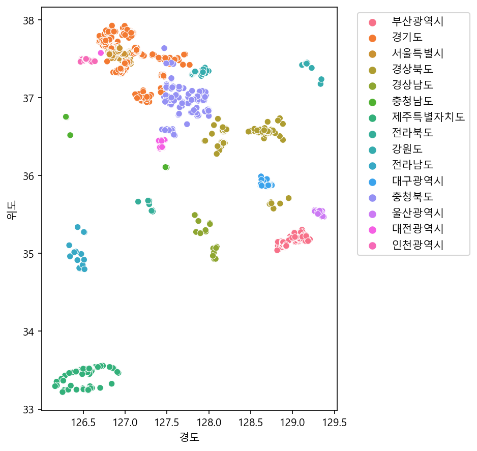

```python
fig=plt.figure(figsize=(5,7), dpi=150)
ax=fig.subplots()

d1 = pd.read_csv('data/dat6.csv', sep=',', encoding='cp949')
d1 = d1.loc[(d1["경도"] < 132) & (d1["위도"] > 32)].copy()
d1=d1.drop(columns='Unnamed: 19')
d1=d1.dropna(subset=['공원구분','소재지지번주소','지정고시일'])
d1['시도']=d1["소재지지번주소"].map(lambda x: x.split(' ')[0]).replace('강원','강원도')
d1.head(2)

## 코드작성


_=ax.legend(bbox_to_anchor=(1.05,1),loc=2)
```

# 문제15

- '인천광역시','대전광역시','대구광역시','광주광역시'의 공원구분 별 공원의 개수를 아래와 같이 4개의 axes에 나타내시오
- 단, searborn의 catplot을 사용하시오 (axe 크기는 적당히 구성, 결과 그림과 똑같을 필요는 없음)

|  | 관리번호 | 공원명 | 공원구분 | 소재지도로명주소 | 소재지지번주소 | 위도 | 경도 | 공원면적 | 공원보유시설(운동시설) | 공원보유시설(유희시설) | 공원보유시설(편익시설) | 공원보유시설(교양시설) | 공원보유시설(기타시설) | 지정고시일 | 관리기관명 | 전화번호 | 데이터기준일자 | 제공기관코드 | 제공기관명 | 시도 |
| --- | --- | --- | --- | --- | --- | --- | --- | --- | --- | --- | --- | --- | --- | --- | --- | --- | --- | --- | --- | --- |
| 0 | 26440-00001 | 구랑공원 | 문화공원 | NaN | 부산광역시 강서구 구랑동 1199-7 | 35.157215 | 128.854935 | 9137.0 | 4 | NaN | 화장실 | NaN | 팔각정자, 파고라2, 평의자6, 앉음벽14.38m, 축구장(골대2), 컨테이너, 안... | 2011-09-02 | 부산광역시 강서구청 녹지공원과 | 051-970-4536 | 2019-05-02 | 3360000 | 부산광역시 강서구 | 부산광역시 |
| 1 | 26440-00002 | 압곡공원 | 근린공원 | NaN | 부산광역시 강서구 구랑동 1219 | 35.154655 | 128.854727 | 33756.0 | 4 | NaN | NaN | NaN | 배드민턴장, 족구장, 파고라4, 안내판, 볼라드7, 데크435.11㎡, 데크계단19... | 2008-02-28 | 부산광역시 강서구청 녹지공원과 | 051-970-4536 | 2019-05-02 | 3360000 | 부산광역시 강서구 | 부산광역시 |

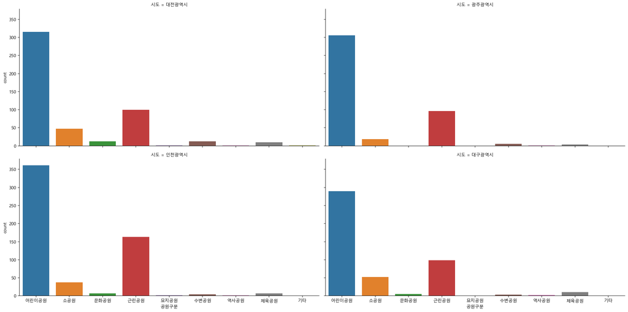

```python
d1 = pd.read_csv('data/dat6.csv', sep=',', encoding='cp949')
d1 = d1.loc[(d1["경도"] < 132) & (d1["위도"] > 32)].copy()
d1=d1.drop(columns='Unnamed: 19')
d1=d1.dropna(subset=['공원구분','소재지지번주소'])
d1['시도']=d1["소재지지번주소"].map(lambda x: x.split(' ')[0]).replace('강원','강원도')
d1.head(2)

## 코드작성


fg.fig.tight_layout()
```

# 문제16

- 경기도, 경상남도, 전라남도의 데이터만 d1에 담았다.
- 위 세 개의 각 도 별로, 공원구분 별 공원의 개수를 그리시오 (seaborn 사용)
- 단, 각 도의 그림을 다른 axes에 그리시오 (axs[0], axs[1] axs[2]에 그림)

|  | 관리번호 | 공원명 | 공원구분 | 소재지도로명주소 | 소재지지번주소 | 위도 | 경도 | 공원면적 | 공원보유시설(운동시설) | 공원보유시설(유희시설) | 공원보유시설(편익시설) | 공원보유시설(교양시설) | 공원보유시설(기타시설) | 지정고시일 | 관리기관명 | 전화번호 | 데이터기준일자 | 제공기관코드 | 제공기관명 | 시도 |
| --- | --- | --- | --- | --- | --- | --- | --- | --- | --- | --- | --- | --- | --- | --- | --- | --- | --- | --- | --- | --- |
| 529 | 46230-00001 | 우산 | 문화공원 | 전라남도 광양시 광양읍 우산리 산39-6 | 전라남도 광양시 광양읍 우산리 산39-6 | 34.985305 | 127.586405 | 288960.0 | 궁도장 | 조합놀이대, 그네 | 주차장, 화장실 | NaN | NaN | 1995-11-14 | 광양시 공원녹지사업소 | 061-797-4979 | 2019-06-17 | 4840000 | 전라남도 광양시 | 전라남도 |
| 530 | 46230-00002 | 덕례98호 | 근린공원 | 전라남도 광양시 광양읍 덕례리 541-1 | 전라남도 광양시 광양읍 덕례리 541-1 | 34.961839 | 127.569952 | 1521.0 | NaN | NaN | NaN | NaN | NaN | 2014-08-28 | 광양시 공원녹지사업소 | 061-797-2512 | 2019-06-17 | 4840000 | 전라남도 광양시 | 전라남도 |

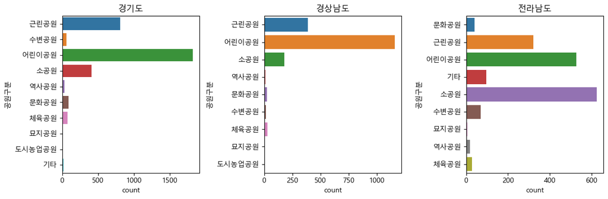

```python
fig=plt.figure(figsize=(12,4), dpi=100)
axs=fig.subplots(1,3).flatten()

d1 = pd.read_csv('data/dat6.csv', sep=',', encoding='cp949')
d1 = d1.loc[(d1["경도"] < 132) & (d1["위도"] > 32)].copy()
d1=d1.drop(columns='Unnamed: 19')
d1=d1.dropna(subset=['공원구분','소재지지번주소'])
d1['시도']=d1["소재지지번주소"].map(lambda x: x.split(' ')[0]).replace('강원','강원도')
d1=d1.loc[d1['시도'].isin(['경기도','경상남도','전라남도'])]
d1.head(2)

## 코드작성

fig.tight_layout()
```